# Methods 4 – Portfolio Assignment 3

## 9. Use the statistical model to do inference

Time to answer the question: which things determine whether people died at Titanic? (or maybe you made some other question that's also okay).

What are the effect sizes? What are their directions?

Make a tiny conclusion here. Maybe try and give a theoretical reason for your results.

And drink some tea or coffee :)

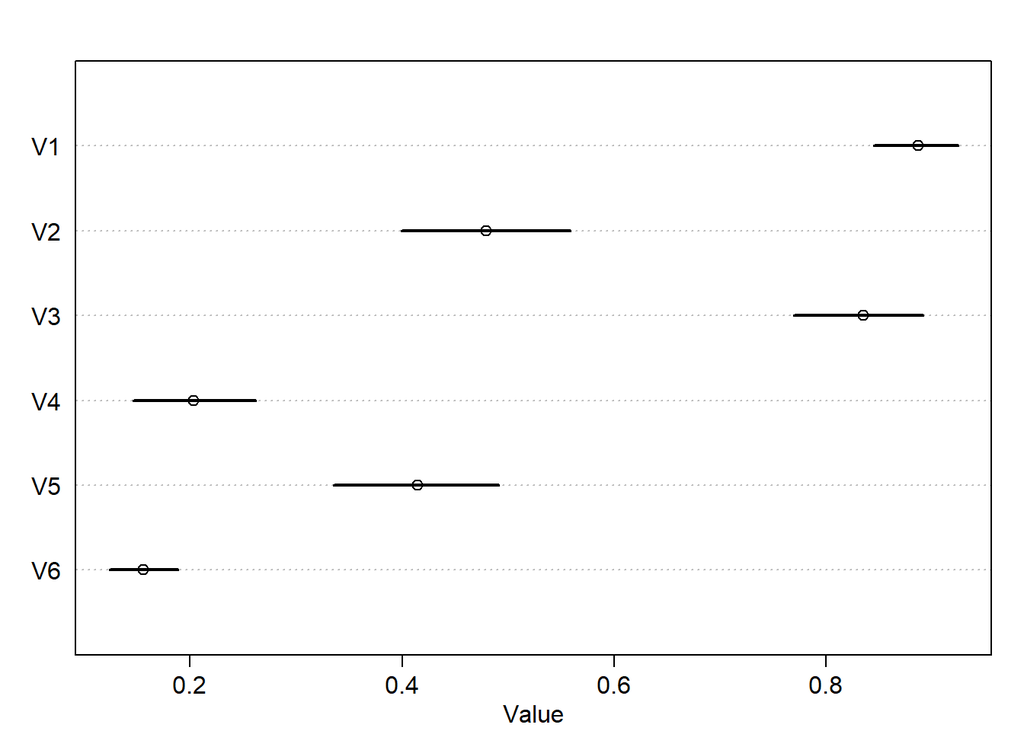

```r
# Effect sizes and posterior predictions
post_int <- extract.samples(m1_real_int)
post_survive <- inv_logit(post_int$I)

labs <- c("Women 1st class", "Women 2nd class", "Women 3rd class", "Men 1st class", "Men 2nd class", "Men 3rd class")
precis_plot(precis(as.data.frame(post_survive), depth = 2))
```

```r
post_precis <- precis(post_int, depth=3)
survive_probability <- inv_logit(post_precis$mean)
Category <- c("Woman 1. Class", "Woman 2. Class", "Woman 3. Class", "Men 1. Class", "Men 2. Class", "Men 3. Class", "Age")

df <- tibble(Category, survive_probability)
df <- df %>%
  filter(Category != "Age")

df
```

| Category | survive_probability |
| --- | --- |
| Woman 1. Class | 0.8893952 |
| Woman 2. Class | 0.4790803 |
| Woman 3. Class | 0.8387224 |
| Men 1. Class | 0.2007061 |
| Men 2. Class | 0.4139096 |
| Men 3. Class | 0.1549220 |

**The above plot shows the predictions from the interaction model, and the data frame shows the average predictions for survival based on the interaction of class and sex.**

**Aboard the Titanic, women travelling on 1st and 3rd class had highest probability of surviving. Both men and women on 2nd class were around chance-level of surviving, a bit lower for men though. Ultimately, according to the model, men on 1st and 3rd class had a very small chance of survival. The estimated parameter for age shows that as age increases, people are less likely to survive, although the effect isn’t that large.**

**Unfortunately, my DAG does not fit the data. Through further exploration of the data, better inference could be made.**